# Assignment 4

## Submit as an HTML file

Print your Emory ID below

```python
print("2670867")
```

```
2670867
```

Import both the MatPlotLib and Numpy libraries

```python
import numpy as np
import matplotlib.pyplot as plt
```

1. For-loops to count conditional statements
- Define a custom list of people's ages

(write down ages for 8 people, between ten and fifty)

- Define an empty list called `list_eligible`
- Use a For-Loop that goes through the ages of the 8 people, then appends the

value `True` to `list_eligible` if their age is greater than or equal to 16  
and `False` otherwise

```python
# Write your own code
people_age=[10,24,25,29,39,40,48,50]
list_eligible=[]
for index in people_age:
    if index >= 16:
        list_eligible.append(True)
    else:
        list_eligible.append(False)

print(list_eligible)
```

```
[False, True, True, True, True, True, True, True]
```

2. This is a follow-up to question 1.
- If you run `np.sum(list_eligible)`, what value is Python assigning to

`True` or `False` elements in the sum? Write you answer as a comment.

- How would you use this information to count the amount of people who are

**NOT** eligible? Write code that answers this question.

```python
# Write your own code
# If I run np.sum(list_eligible), Python is assigning 1 to all True elements and 0 to all false elements.
# This code would count the amount of people who are not eligible:
print(len(people_age)- np.sum(list_eligible))
```

```
1
```

3. Use a For-Loop for message automation
- Write your own list of customer names
- Print an automated message with the unique name of the customer that tells

them they've won a giveaway

- How many messages to do you expect to see? Write code that automatically

prints the size of the customer list

```python
# Write your own code
customer_names = ["Allen", "Andy", "April", "Sean", "Joshua", "Thomas", "Rudy", "Josh"]
for customer in customer_names:
    print("Congratulations! " + customer + " You've won our giveaway!")

print("Total number of customers: " + str(len(customer_names)))
```

```
Congratulations! Allen You've won our giveaway!
Congratulations! Andy You've won our giveaway!
Congratulations! April You've won our giveaway!
Congratulations! Sean You've won our giveaway!
Congratulations! Joshua You've won our giveaway!
Congratulations! Thomas You've won our giveaway!
Congratulations! Rudy You've won our giveaway!
Congratulations! Josh You've won our giveaway!
Total number of customers: 8
```

4. For-Loops + Plotting
- Create an array of x-values with all the integers between 1 and 10
- Create a vector `vec_y1` where each element is computed from

the formula $ y_1 = 0.5x^4 + 2x^2 + 4x$.

- Create a vector `vec_y2` where each element is computed from

the formula $ y_2 = 2x^3 + 4x + 4$.

- Create an object `list_vectors` with elements `vec_y1` and `vec_y2`
- Create a for-loop that goes through each element of

`list_vectors` and plots each list of $y$ values against $x$

Note: The final output should be a 2 dimensional scatter plot with two sets,  
of points, with the $y_1$ and $y_2$ on the vertical axis, and the $x$ values  
on the horizontal axis. Remember to always label the axes to make it look  
more professional.

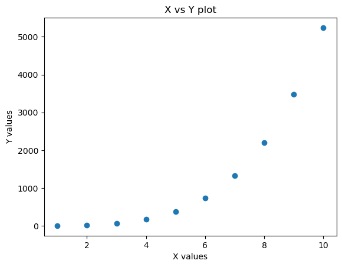

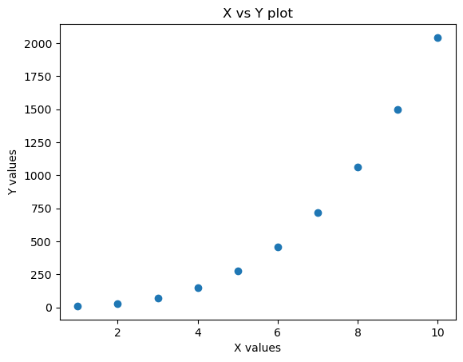

```python
# Write your own code
x_values = np.array(range(1, 11))

# Step 2: Create vector vec_y1 using the formula y1 = 0.5x^4 + 2x^2 + 4x
vec_y1 = 0.5 * x_values**4 + 2 * x_values**2 + 4 * x_values

# Step 3: Create vector vec_y2 using the formula y2 = 2x^3 + 4x + 4
vec_y2 = 2 * x_values**3 + 4 * x_values + 4

# Step 4: Create a list with the two vectors
list_vectors = [vec_y1, vec_y2]

for element in list_vectors:
    plt.scatter(x_values, element)
    plt.xlabel("X values")
    plt.ylabel("Y values")
    plt.title("X vs Y plot")
    plt.show()
```

5. Loops + Multiple Lists

Before starting, read the following information about nested loops:

https://www.w3schools.com/python/gloss_python_for_nested.asp

[figure not shown]

- Convert the following three lists to arrays

`list_lower = [93, 87, 83, 80, 75, 70, 65, 60, 55, 0]`  
`list_upper = [100,92, 86, 82, 79, 74, 69, 64, 59, 54]`  
`list_letters = ["A","A-","B+","B","B-","C+","C","C-","D","F"]`

- Convert the following list of student grades to an array

`list_studentgrades = [80, 70, 96, 65, 92]`

- Create a nested for-loop that outputs

"The student got a numeric grade of .... and their letter grade was ..."

Example of the procedure:

1. Start with the first student on the list, who's grade is 80.
2. Check whether the student's grade is an A by checking whether 80 is between

93 and 100. Then check whether it's a B by checking whether the grade is between  
87 and 92, and so on. This is the "inner loop". 3. Within the inner loop, if you find the right grade bracket, print the  
desired message. Else, do not print anything. 4. Do this procedure for all students, i.e. the "outer loop".

```python
# Write your own code
list_lower = [93, 87, 83, 80, 75, 70, 65, 60, 55, 0]
list_upper = [100, 92, 86, 82, 79, 74, 69, 64, 59, 54]
list_letters = ["A", "A-", "B+", "B", "B-", "C+", "C", "C-", "D", "F"]

arr_lower = np.array(list_lower)
arr_upper = np.array(list_upper)
arr_letters = np.array(list_letters)

list_studentgrades = [80,70,96,65,92]
arr_studentgrades = np.array(list_studentgrades)
index=0
for element in arr_studentgrades:
    for index in range(len(arr_lower)):
        if arr_lower[index] <= element <= arr_upper[index]:
            print("The student got a numeric grade of " + str(element) + " and their letter grade was " + arr_letters[index])
            break
```

```
The student got a numeric grade of 80 and their letter grade was B
The student got a numeric grade of 70 and their letter grade was C+
The student got a numeric grade of 96 and their letter grade was A
The student got a numeric grade of 65 and their letter grade was C
The student got a numeric grade of 92 and their letter grade was A-
```